# Lab 5

# Age, Sex linear model

This model is also clearly not a good fit with an r^2 score of 0.125 and high MSE and MAE scores. This model would predict that an increase in 1 year of age would increase the charge by $209.3 and a patient being male would increase the charge by $1473.5 compared to being female.

```python
y = df['charges']
X = df[['age', 'sex_male']]

X_train, X_test, y_train, y_test = train_test_split(X, y, test_size=0.25, random_state=42)

lr_fitted_a_s = lr.fit(X_train, y_train)
y_pred = lr_fitted_a_s.predict(X_test)

print("MSE: " + str(mean_squared_error(y_test, y_pred)))
print("MAE: " + str(mean_absolute_error(y_test, y_pred)))
print("R^2: " + str(r2_score(y_test, y_pred)))

print("Intercept:", lr_fitted_a_s.intercept_)
print("Coefficients:", lr_fitted_a_s.coef_)
```

```
MSE: 123710493.45774047
MAE: 8628.547265231322
R^2: 0.1252114734047708
Intercept: 3755.226264005276
Coefficients: [ 209.29665278 1473.52604363]
```

# Age, Smoker linear model

This model is a significantly better fit with an r^2 score of 0.807 and significantly lower MSE and MAE scores than the previous models. This model would predict charges increase by $247.9 given an increase of 1 year of age and an increase of $23783.2 for a smoker vs a non-smoker.

```python
y = df['charges']
X = df[['age', 'smoker_yes']]

X_train, X_test, y_train, y_test = train_test_split(X, y, test_size=0.25, random_state=42)

lr_fitted_a_sm = lr.fit(X_train, y_train)
y_pred = lr_fitted_a_sm.predict(X_test)

print("MSE: " + str(mean_squared_error(y_test, y_pred)))
print("MAE: " + str(mean_absolute_error(y_test, y_pred)))
print("R^2: " + str(r2_score(y_test, y_pred)))

print("Intercept:", lr_fitted_a_sm.intercept_)
print("Coefficients:", lr_fitted_a_sm.coef_)
```

```
MSE: 27352787.78429866
MAE: 3358.4149176910946
R^2: 0.8065814446672434
Intercept: -1924.8183280556186
Coefficients: [  247.96864143 23783.23782356]
```

# Results

The Age, Smoker linear model is clearly the best with an r^2 value of 0.8 vs ~0.1 for the other two, and an MSE of ~2.7e7 while the other two models have MSE values of ~1.2e8

# Age, BMI linear model

This model is slightly better than the original age lr model, however the slightly higher r^2 value and sightly lower MSE may be a result of the test/training split and could possibly switch which model scores better given a different split.

```python
y = df['charges']
X = df[['age', 'bmi']]

X_train, X_test, y_train, y_test = train_test_split(X, y, test_size=0.25, random_state=42)

lr_fitted_a_b = lr.fit(X_train, y_train)
y_pred = lr_fitted_a_b.predict(X_test)

print("MSE: " + str(mean_squared_error(y_test, y_pred)))
print("MAE: " + str(mean_absolute_error(y_test, y_pred)))
print("R^2: " + str(r2_score(y_test, y_pred)))

print("Intercept:", lr_fitted_a_b.intercept_)
print("Coefficients:", lr_fitted_a_b.coef_)
```

```
MSE: 117716955.13097996
MAE: 8476.314257849206
R^2: 0.16759331519857057
Intercept: -3468.719830867887
Coefficients: [199.60006815 270.53353676]
```

# Age^2, BMI linear model

This model is almost identical to the previous age, BMI model with almost no variation in r^2 and MSE scores.

```python
df['age2'] = df['age']**2
y = df['charges']
X = df[['age', 'age2', 'bmi']]

X_train, X_test, y_train, y_test = train_test_split(X, y, test_size=0.25, random_state=42)

lr_fitted_a2_b = lr.fit(X_train, y_train)
y_pred = lr_fitted_a2_b.predict(X_test)

print("MSE: " + str(mean_squared_error(y_test, y_pred)))
print("MAE: " + str(mean_absolute_error(y_test, y_pred)))
print("R^2: " + str(r2_score(y_test, y_pred)))

print("Intercept:", lr_fitted_a2_b.intercept_)
print("Coefficients:", lr_fitted_a2_b.coef_)
```

```
MSE: 117672740.51899774
MAE: 8449.062016411985
R^2: 0.1679059680236369
Intercept: -5770.532426443051
Coefficients: [331.21660473  -1.6527677  274.52595778]
```

# Age, BMI multiple linear model (Age degree 4)

This model, while still not great, is definitely better than the original with an r^2 of 0.18 vs 0.139 and an MSE of 1.16e8 vs 1.22e8

```python
y = df['charges']
X = df[['age', 'bmi']]

X_train, X_test, y_train, y_test = train_test_split(X, y, test_size=0.25, random_state=42)

ct = ColumnTransformer(
    transformers=[
        ("poly_age", PolynomialFeatures(degree=4, include_bias=False), ["age"]),
        ("pass_bmi", "passthrough", ["bmi"])
    ]
)

mlr = Pipeline([
    ("transform", ct),
    ("linreg", LinearRegression())
])

mlr_fitted_a_b = mlr.fit(X_train, y_train)
y_pred = mlr_fitted_a_b.predict(X_test)

print("MSE: " + str(mean_squared_error(y_test, y_pred)))
print("MAE: " + str(mean_absolute_error(y_test, y_pred)))
print("R^2: " + str(r2_score(y_test, y_pred)))
```

```
MSE: 115943212.98359852
MAE: 8345.740836287652
R^2: 0.1801358993908947
```

# Age, BMI multiple linear model (Age degree 12)

This model is clearly overfit with an r^2 of 0.136 and an MSE of 1.22e8, almost identical scores from the original model

```python
y = df['charges']
X = df[['age', 'bmi']]

X_train, X_test, y_train, y_test = train_test_split(X, y, test_size=0.25, random_state=42)

ct = ColumnTransformer(
    transformers=[
        ("poly_age", PolynomialFeatures(degree=12, include_bias=False), ["age"]),
        ("pass_bmi", "passthrough", ["bmi"])
    ]
)

mlr = Pipeline([
    ("transform", ct),
    ("linreg", LinearRegression())
])

mlr_fitted_a_b = mlr.fit(X_train, y_train)
y_pred_12 = mlr_fitted_a_b.predict(X_test)

print("MSE: " + str(mean_squared_error(y_test, y_pred_12)))
print("MAE: " + str(mean_absolute_error(y_test, y_pred_12)))
print("R^2: " + str(r2_score(y_test, y_pred_12)))
```

```
MSE: 122174752.0589032
MAE: 8563.552001781924
R^2: 0.13607109345777035
```

# Results

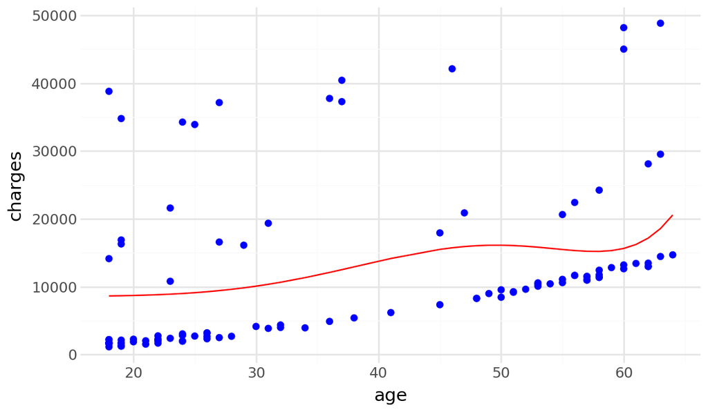

```python
df_plot = pd.DataFrame({
    "age": X_test["age"],
    "charges": y_test,
    "predicted": y_pred_12
}).sort_values("age")

(
    ggplot(df_plot, aes(x="age"))
    + geom_point(aes(y="charges"), color="blue")
    + geom_line(aes(y="predicted"), color="red")
    + theme_minimal()
)
```

# New Data

```python
df_old = df
df_new = pd.read_csv("https://www.dropbox.com/s/sky86agc4s8c6qe/insurance_costs_2.csv?dl=1")
df_new = pd.get_dummies(df_new, columns=['sex', 'smoker', 'region'], drop_first=True)

df_new.head()
```

|  | age | bmi | charges | sex_male | smoker_yes | region_northwest | region_southeast | region_southwest |
| --- | --- | --- | --- | --- | --- | --- | --- | --- |
| 0 | 23 | 34.400 | 1826.84300 | True | False | False | False | True |
| 1 | 56 | 40.300 | 10602.38500 | True | False | False | False | True |
| 2 | 18 | 34.100 | 1137.01100 | True | False | False | True | False |
| 3 | 63 | 23.085 | 14451.83515 | False | False | False | False | False |
| 4 | 63 | 28.310 | 13770.09790 | True | False | True | False | False |

# New Data Models

The final model (~ (age + bmi)*smoker) appears to be the best with the lowest MSE value.

```python
df_old['age_smoker'] = df_old['age'] * df_old['smoker_yes']
df_old['bmi_smoker'] = df_old['bmi'] * df_old['smoker_yes']
df_new['age_smoker'] = df_new['age'] * df_new['smoker_yes']
df_new['bmi_smoker'] = df_new['bmi'] * df_new['smoker_yes']

mse = []

y_train = df_old['charges']
X_train = df_old[['age']]
y_test = df_new['charges']
X_test = df_new[['age']]

lr_fitted = lr.fit(X_train, y_train)
y_pred = lr_fitted.predict(X_test)

mse.append(mean_squared_error(y_test, y_pred))

y_train = df_old['charges']
X_train = df_old[['age', 'bmi']]
y_test = df_new['charges']
X_test = df_new[['age', 'bmi']]

lr_fitted = lr.fit(X_train, y_train)
y_pred = lr_fitted.predict(X_test)

mse.append(mean_squared_error(y_test, y_pred))

y_train = df_old['charges']
X_train = df_old[['age', 'bmi', 'smoker_yes']]
y_test = df_new['charges']
X_test = df_new[['age', 'bmi', 'smoker_yes']]

lr_fitted = lr.fit(X_train, y_train)
y_pred = lr_fitted.predict(X_test)

mse.append(mean_squared_error(y_test, y_pred))

y_train = df_old['charges']
X_train = df_old[['age', 'bmi', 'age_smoker', 'bmi_smoker']]
y_test = df_new['charges']
X_test = df_new[['age', 'bmi', 'age_smoker', 'bmi_smoker']]

lr_fitted = lr.fit(X_train, y_train)
y_pred = lr_fitted.predict(X_test)

mse.append(mean_squared_error(y_test, y_pred))

y_train = df_old['charges']
X_train = df_old[['age', 'bmi', 'age_smoker', 'bmi_smoker', 'smoker_yes']]
y_test = df_new['charges']
X_test = df_new[['age', 'bmi', 'age_smoker', 'bmi_smoker', 'smoker_yes']]

lr_fitted = lr.fit(X_train, y_train)
y_pred = lr_fitted.predict(X_test)

mse.append(mean_squared_error(y_test, y_pred))

print(mse)
```

```
[136077136.50195494, 132636406.1108129, 35377541.24141631, 24795908.41264335, 21786256.86685259]
```

# Plotting residuals

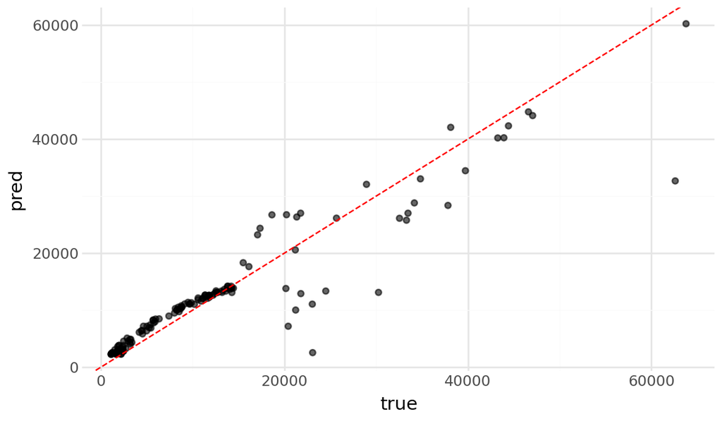

```python
df_plot = pd.DataFrame({
    "true": y_test,
    "pred": y_pred,
})

df_plot["residual"] = df_plot["true"] - df_plot["pred"]

(
    ggplot(df_plot, aes(x="true", y="pred"))
    + geom_point(alpha=0.6)
    + geom_abline(color="red", linetype="dashed")
    + theme_minimal()
)
```

# Best model

```python
df_old['age^2'] = df_old['age']**2
df_old['bmi^2'] = df_old['bmi']**2
df_new['age^2'] = df_new['age']**2
df_new['bmi^2'] = df_new['bmi']**2
y_train = df_old['charges']
X_train = df_old[['age', 'age^2', 'bmi', 'bmi^2', 'age_smoker', 'bmi_smoker', 'smoker_yes']]
y_test = df_new['charges']
X_test = df_new[['age', 'age^2', 'bmi', 'bmi^2', 'age_smoker', 'bmi_smoker', 'smoker_yes']]

lr_fitted = lr.fit(X_train, y_train)
y_pred = lr_fitted.predict(X_test)

print("MSE: " + str(mean_squared_error(y_test, y_pred)))
print("R^2: " + str(r2_score(y_test, y_pred)))
```

```
MSE: 21530779.44507097
R^2: 0.8611363912486582
```

# Plotting residuals

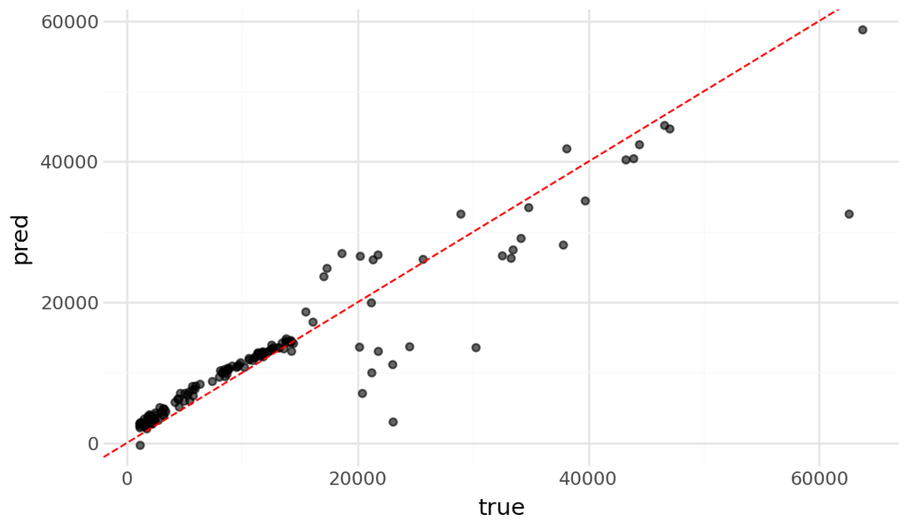

```python
df_plot = pd.DataFrame({
    "true": y_test,
    "pred": y_pred,
})

df_plot["residual"] = df_plot["true"] - df_plot["pred"]

(
    ggplot(df_plot, aes(x="true", y="pred"))
    + geom_point(alpha=0.6)
    + geom_abline(color="red", linetype="dashed")
    + theme_minimal()
)
```